# Clustering & decision trees

Monday, June 22, 2026

**NoteToday: Monday June 22**

**Before class**

- **Perusall Reading** (Canvas): *Data Computing* [§18.2 (clustering)](https://psu.instructure.com/courses/2487468/assignments/18325380)

**Plan for today**

- **Quiz 4** (rescheduled from Friday).
- **Supervised vs. unsupervised** learning.
- **k-means** and **hierarchical** clustering.
- **Decision trees / CART**.
- In-class activity.

**Helpful links**

- Syllabus · Schedule · [*DC* Ch. 18](https://dtkaplan.github.io/DataComputingEbook/chap-machine-learning.html)

# Big picture

## Two kinds of learning

|  | **Unsupervised** | **Supervised** |
| --- | --- | --- |
| You have… | features only, **no labels** | features **and** a known answer |
| Goal | find **structure / groups** | **predict** the answer for new cases |
| Examples | **clustering** (k-means, hierarchical) | **decision trees** (CART) |
| “Right answer”? | no; you judge usefulness | yes; you can measure accuracy |

Today, we’ll be using the **Palmer penguins** body measurements to explore supervised and unsupervised learning techniques.

## Penguins data

```r
peng |>
  select(species, bill_length_mm, bill_depth_mm, flipper_length_mm, body_mass_g) |>
  glimpse()
```

```
Rows: 342
Columns: 5
$ species           <fct> Adelie, Adelie, Adelie, Adelie, Adelie, Adelie, Adel…
$ bill_length_mm    <dbl> 39.1, 39.5, 40.3, 36.7, 39.3, 38.9, 39.2, 34.1, 42.0…
$ bill_depth_mm     <dbl> 18.7, 17.4, 18.0, 19.3, 20.6, 17.8, 19.6, 18.1, 20.2…
$ flipper_length_mm <int> 181, 186, 195, 193, 190, 181, 195, 193, 190, 186, 18…
$ body_mass_g       <int> 3750, 3800, 3250, 3450, 3650, 3625, 4675, 3475, 4250…
```

For **clustering** we’ll hide `species` and see if we can “rediscover” these categories. For **trees** we’ll use `species` as the answer to predict.

# Clustering

## Overview

**Clustering** puts rows into groups so that rows in a group are **similar** and rows in different groups are **different**, using only the feature columns.

- No labels go into the model, i.e., you don’t tell it “species.”
- “Similar” means **close in distance** once features are on a comparable scale.
- How we measure distance depends on the method.

**Warning**

**Scale first.** Body mass (~3000-6000 g) would swamp bill depth (~13-22 mm) in any distance calculation. We almost always want to standardize so every feature gets an equal vote.

```r
X <- peng |>
  select(bill_length_mm, bill_depth_mm, flipper_length_mm, body_mass_g) |>
  scale() # subtract mean, divide by sd --> unit-less

round(colMeans(X), 14) # column means = zero
```

```
   bill_length_mm     bill_depth_mm flipper_length_mm       body_mass_g
                0                 0                 0                 0
```

```r
apply(X, 2, var) # column variances = one
```

```
   bill_length_mm     bill_depth_mm flipper_length_mm       body_mass_g
                1                 1                 1                 1
```

## k-means clustering

`kmeans()` finds **k** cluster centers and assigns each point to its nearest one, iterating until things stop moving. **k** is a hyperparameter you pick.

```r
set.seed(184) # random algorithm; set a seed so results are reproducible
km <- kmeans(X, centers = 3, nstart = 25) # nstart = try 25 random starts, keep best
km$size # how many penguins per cluster
```

```
[1] 132  87 123
```

`nstart` matters here: k-means depends on random starting centers, so we try several and keep the best.

- `set.seed()` makes it reproducible (we’ll get the same results if we re-run our code).

## Clustering results

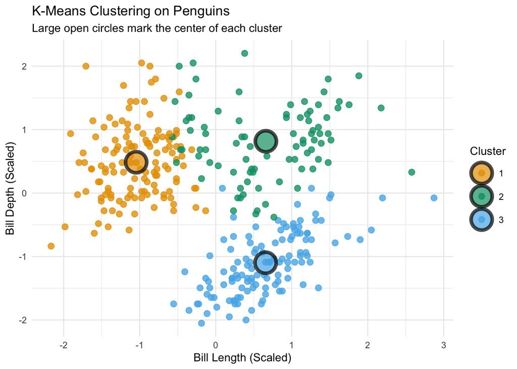

## Did it recover the species categories?

We clustered **without** species. Now compare the clusters to the real species:

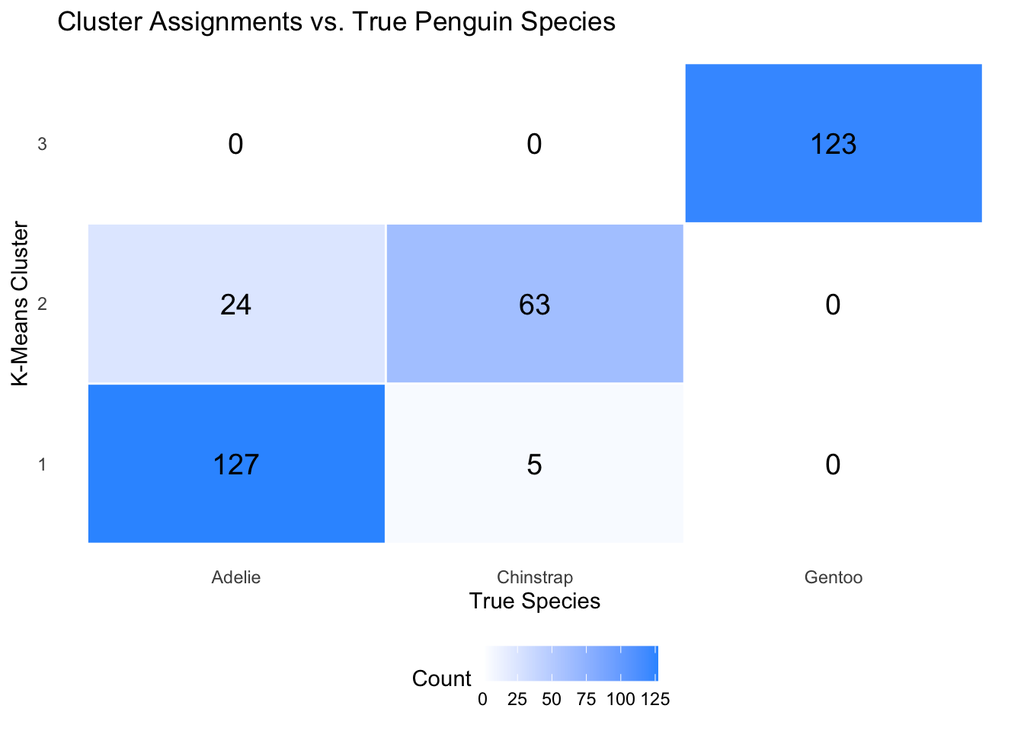

## Did it recover the species categories?

[figure not shown]

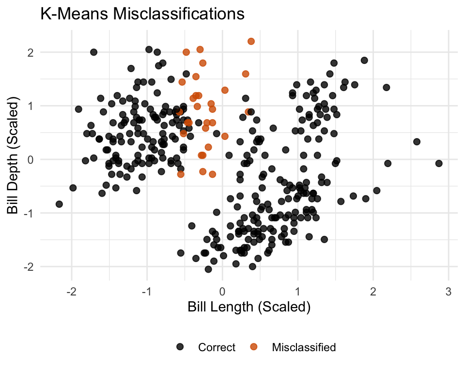

Each cluster is mostly one species, found with **no labels**. (Gentoo separates cleanly; the other two overlap a bit.)

## How many clusters? The elbow

There’s no “correct” **k**. A common heuristic is to plot total within-cluster spread as **k** grows, and look for the **elbow** where adding clusters stops helping. (Uses `purrr::map_dbl()` from last week.)

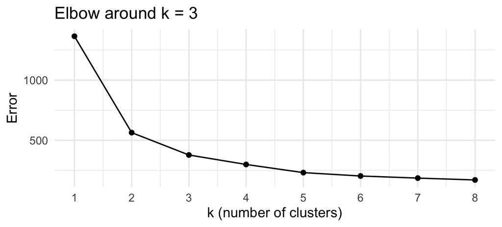

```r
tibble(k = 1:8) |>
  mutate(wss = map_dbl(k, ~ kmeans(X, centers = .x, nstart = 10)$tot.withinss)) |>
  ggplot(aes(k, wss)) +
  geom_line() + geom_point(size = 2) +
  scale_x_continuous(breaks = 1:8) +
  labs(x = "k (number of clusters)", y = "Error",
       title = "Elbow around k = 3")
```

Here, “Error” is measured by the total within-cluster sum of squares:

$$\text{Error}_k = \sum_{i=1}^{N} ||\mathbf{x}_i - \boldsymbol{\mu}_{c(i)}||^2$$

Equivalently,

$$\text{Error}_k = \sum_{j=1}^{k} \sum_{\mathbf{x}_i \in C_j} ||\mathbf{x}_i - \boldsymbol{\mu}_j||^2$$

## Hierarchical clustering

Another approach is to not pick **k** up front. Instead, you can start with every point alone, then repeatedly **merge the two closest groups**, and record the whole tree (a **dendrogram**).

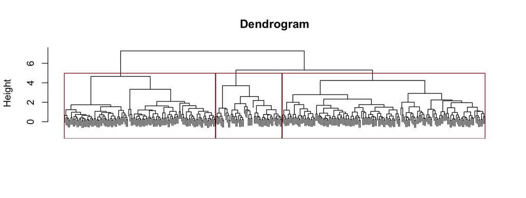

```r
d  <- dist(X) # pairwise distances
hc <- hclust(d, method = "complete")
plot(hc, labels = FALSE, main = "Dendrogram", xlab = "", sub = "")
rect.hclust(hc, k = 3, border = "#7C0A02") # cut into 3 groups
```

**Height** = how different two groups were when merged. **Cut** the tree at a height to get clusters, then you choose *after* seeing the structure.

## Hierarchical: cut and compare

```r
clusters_h <- cutree(hc, k = 3)
table(cluster = clusters_h, species = peng$species)
```

```
       species
cluster Adelie Chinstrap Gentoo
      1    151        14      0
      2      0         0    123
      3      0        54      0
```

k-means needs **k** up front and is fast on big data; hierarchical shows the **whole nesting structure** and lets you decide **k** afterward.

# Decision trees (CART)

## Now we *have* labels

Switch to **supervised**: use the measurements to **predict species**, and get a model a human can read.

A **decision tree** asks a sequence of yes/no questions about the features, splitting the data at each step, until each leaf is (mostly) one class. **CART** = Classification And Regression Trees.

```r
fit <- rpart(
  species ~ bill_length_mm + bill_depth_mm + flipper_length_mm + body_mass_g,
  data = peng, method = "class"
)
```

## Read the tree

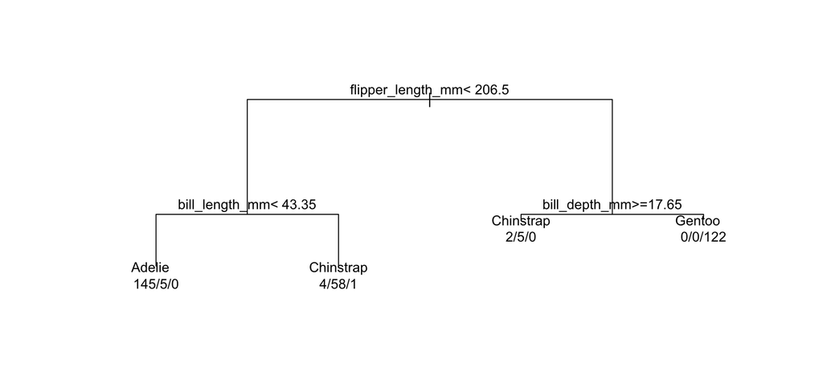

```r
plot(fit, margin = 0.1)
text(fit, use.n = TRUE, cex = 0.9)
```

Follow a penguin from the top: at each node, answer the question and go **left if yes**. The leaf is the predicted species. Notice it often needs only **two measurements**, which is much more interpretable.

## How does it pick the splits?

At each step the tree tries every feature and every cut point and keeps the split that makes the two sides **most “pure”** (closest to a single class).

- Purity is measured by **impurity** (Gini index): low impurity = the node is almost all one species.
- It splits **greedily**, top-down, then **stops** when splits no longer help enough.

**Tip**

This is why trees are easy to explain: each split is just a threshold on one variable, like `flipper_length_mm < 206`.

## How good is it?

Because species is known, we can **score** predictions with a confusion table:

```r
pred <- predict(fit, peng, type = "class")
table(prediction = pred, actual = peng$species)
```

```
           actual
prediction  Adelie Chinstrap Gentoo
  Adelie       145         5      0
  Chinstrap      6        63      1
  Gentoo         0         0    122
```

```r
mean(pred == peng$species) # overall accuracy
```

```
[1] 0.9649123
```

## Visualize with a heatmap

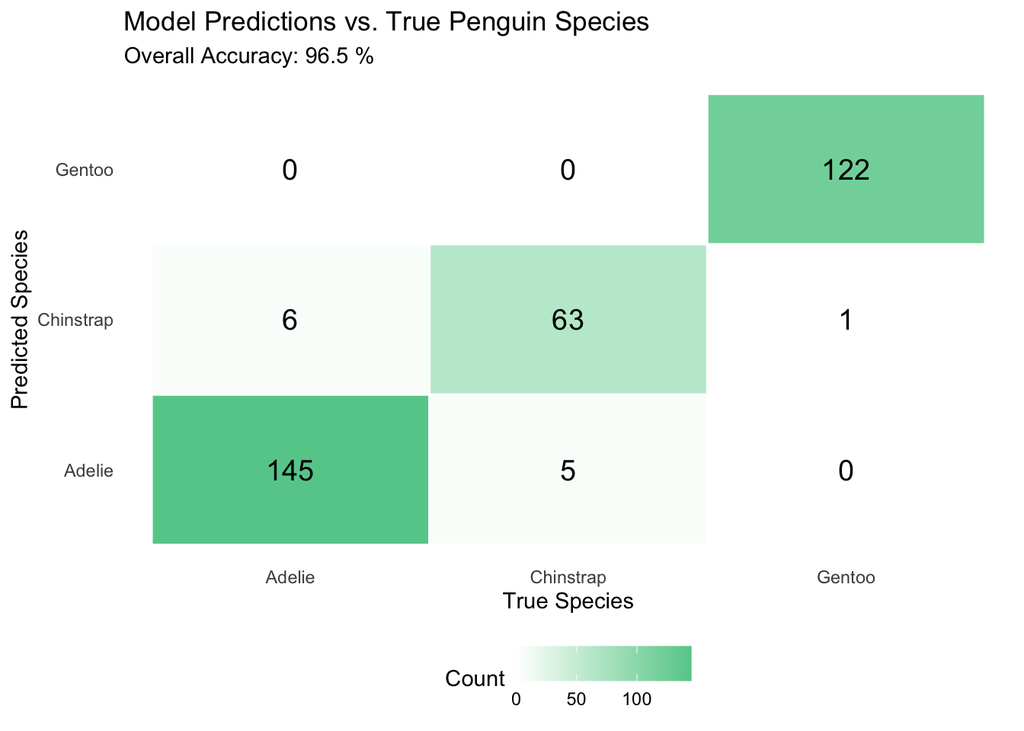

**Warning**

This is accuracy on the **same data the tree learned from**, which is overly optimistic. A more realistic evaluation uses a held-out **test set** (the model must perform on data it has never seen). Deep trees can **overfit**, i.e., memorize the training data, fail on new data.

## Trees vs. clustering

**Clustering (unsupervised)**

- No labels available
- Question: *“what natural groups exist?”*
- Output: a group ID per row
- Judged by usefulness, not accuracy
- e.g. customer segments, document topics

**Decision tree (supervised)**

- Labels available
- Question: *“predict this known outcome”*
- Output: a prediction + a readable rule
- Judged by accuracy on held-out data
- e.g. spam / not-spam, species, churn

An unsupervised cluster is **not** a verified truth, it’s a hypothesis you still have to check.

# Activity

## In-class activity (~20 min)

Work in `day24-activity.R` (or a fresh script) on the `penguins` data.

1. **Cluster.** Standardize the four numeric measurements, run `kmeans()` with `centers = 2`, then `4`. How does `table(cluster, species)` change vs. `k = 3`?
2. **Elbow.** Rebuild the elbow plot using only **two** features. Does the elbow still say 3?
3. **Tree.** Fit a tree predicting `species` from **only** `bill_length_mm` and `bill_depth_mm`. Plot it and report accuracy. Did dropping two features hurt much?
4. **Discuss.** Which method would you prefer if the dataset had **no** `species` column at all? Why?

## Wrap-up & looking ahead

**What we covered**

- **Unsupervised** (clustering) finds groups with no labels; **supervised** (trees) predicts a known label.
- **k-means**: pick `k`, scale features, `nstart`, read the elbow.
- **Hierarchical**: merge-closest, read the dendrogram, cut afterward.
- **Trees**: greedy splits on single features $\rightarrow$ readable rules; score on **held-out** data, beware overfitting.

**Upcoming**

- **Tue Jun 23:** using R with LLMs · HW 5 due 11:59 p.m.
- **Wed Jun 24:** case study · Checkpoint 2 due

**Reach out**

Stuck? Office hours, or email me (cgc5478@psu.edu) or Xinyue (xpw5228@psu.edu).

**Reference**

- [*DC* Ch. 18](https://dtkaplan.github.io/DataComputingEbook/chap-machine-learning.html)
- Syllabus · Schedule